# Quick start

# Quick start to `covidregionaldata`

`covidregionaldata` is designed to extract national and subnational Covid-19 data from publicly available sources, both daily and aggregated over time.

For example, we could:

- Get the Covid-19 cases and deaths for all countries for each day since reporting began.
- Get the total Covid-19 cases and deaths for all countries up to today.
- Get the number of new cases for each state in the United States over time.
- Get the total number of deaths for all local authorities in the United Kingdom.

We will demonstrate some of these examples below, as well as some useful data manipulation and visualisation.

## Retrieving national cases and deaths over time

Let’s say that we want to see the evolution of the pandemic over time in all countries. To do this, we need to get the number of cases (positive test results) and deaths for each country and date since the pandemic started. Firstly load `covidregionaldata`, then call `get_national_data()`:

```r
library(covidregionaldata)
all_countries <- get_national_data()
```

```
#>
#> Cleaning data
#>
#> Processing data
```

We can take a look at this data by printing it to the console:

```r
all_countries
```

```
#> # A tibble: 181,068 × 15
#>    date       un_region who_region country        iso_code cases_new cases_total
#>    <date>     <chr>     <chr>      <chr>          <chr>        <dbl>       <dbl>
#>  1 2020-01-03 Asia      EMRO       Afghanistan    AF               0           0
#>  2 2020-01-03 Europe    EURO       Albania        AL               0           0
#>  3 2020-01-03 Africa    AFRO       Algeria        DZ               0           0
#>  4 2020-01-03 Oceania   WPRO       American Samoa AS               0           0
#>  5 2020-01-03 Europe    EURO       Andorra        AD               0           0
#>  6 2020-01-03 Africa    AFRO       Angola         AO               0           0
#>  7 2020-01-03 Americas  AMRO       Anguilla       AI               0           0
#>  8 2020-01-03 Americas  AMRO       Antigua & Bar… AG               0           0
#>  9 2020-01-03 Americas  AMRO       Argentina      AR               0           0
#> 10 2020-01-03 Asia      EURO       Armenia        AM               0           0
#> # … with 181,058 more rows, and 8 more variables: deaths_new <dbl>,
#> #   deaths_total <dbl>, recovered_new <dbl>, recovered_total <dbl>,
#> #   hosp_new <dbl>, hosp_total <dbl>, tested_new <dbl>, tested_total <dbl>
```

We can see that this provides information about the number of cases and deaths for each country over time. As a tibble is returned, we can easily manipulate and plot this using `tidyverse` packages. For example, we can plot the total deaths in Italy over time.

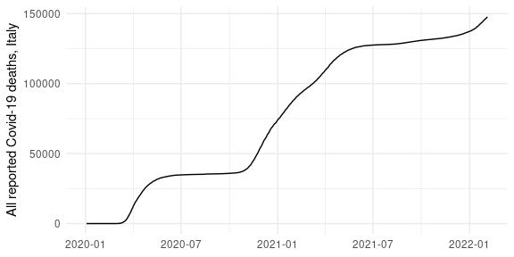

```r
library(dplyr)
library(ggplot2)

all_countries %>%
  filter(country == "Italy") %>%
  ggplot() +
  aes(x = date, y = deaths_total) +
  geom_line() +
  labs(x = NULL, y = "All reported Covid-19 deaths, Italy") +
  theme_minimal()
```

We could have also filtered by country using `get_national_data(countries = "Italy")` to achieve the same result.

To plot the evolution of cases for several countries since the start of the pandemic, we could perform something like the following:

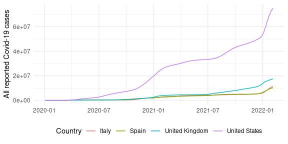

```r
all_countries %>%
  filter(country %in% c(
    "Italy", "United Kingdom", "Spain",
    "United States"
  )) %>%
  ggplot() +
  aes(x = date, y = cases_total, colour = country) +
  geom_line() +
  labs(x = NULL, y = "All reported Covid-19 cases", colour = "Country") +
  theme_minimal() +
  theme(legend.position = "bottom")
```

## Retrieving total cases and deaths for all countries

Using `get_national_data(totals = TRUE)` we can obtain total cases and deaths for all nations up to the latest date reported. This is useful to get a snapshot of the current running total for each country. Note how the data is sorted by the total number of cases:

```r
all_countries_totals <- get_national_data(totals = TRUE, verbose = FALSE)
all_countries_totals
```

```
#> # A tibble: 236 × 7
#>    country        iso_code cases_total deaths_total recovered_total hosp_total
#>    <chr>          <chr>          <dbl>        <dbl>           <dbl>      <dbl>
#>  1 United States  US          75087972       888113               0          0
#>  2 India          IN          41952717       500055               0          0
#>  3 Brazil         BR          25793685       628960               0          0
#>  4 France         FR          19596336       129042               0          0
#>  5 United Kingdom GB          17607836       157730               0          0
#>  6 Russia         RU          12452765       334039               0          0
#>  7 Turkey         TR          11939804        88064               0          0
#>  8 Italy          IT          11348701       147765               0          0
#>  9 Germany        DE          10671602       118504               0          0
#> 10 Spain          ES          10199716        94040               0          0
#> # … with 226 more rows, and 1 more variable: tested_total <dbl>
```

## Retrieving subnational region data

As well as national data, we can also retrieve subnational data, such as states and counties in the US, or regions and local authorities in the UK, and perform similar manipulations. See the [README](https://epiforecasts.io/covidregionaldata/) for a current list of countries with subnational data.

To do this, we use `get_regional_data()` (we could also use the underlying method as follows `us <- USA$new(get = TRUE); us$return()`). We’ll get the state-level data for the United States over time:

```r
usa_states <- get_regional_data(country = "USA")
```

```
#>
#> Cleaning data
#>
#> Processing data
```

This retrieves the new and total cases and deaths for all states over time in the United States. Note that the `country` argument to the `get_regional_data()` function must be specified. Let’s plot out how the number of cases has evolved for a selection of states:

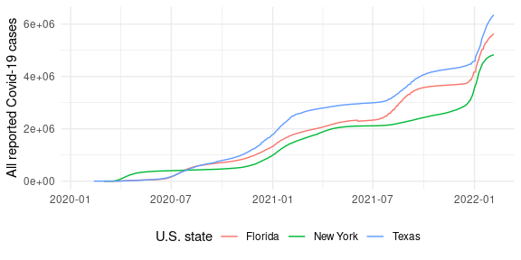

```r
usa_states %>%
  filter(state %in% c("New York", "Texas", "Florida")) %>%
  ggplot() +
  aes(x = date, y = cases_total, colour = state) +
  geom_line() +
  labs(x = NULL, y = "All reported Covid-19 cases", colour = "U.S. state") +
  theme_minimal() +
  theme(legend.position = "bottom")
```

```r
usa_states_totals <- get_regional_data(
  country = "USA", totals = TRUE,
  verbose = FALSE
)
```

Let’s plot the total deaths for each state, ordered by total deaths:

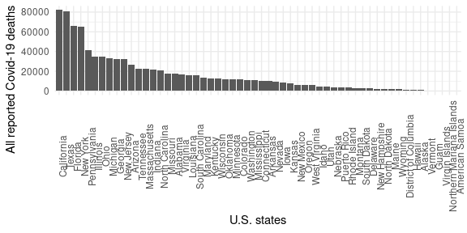

```r
usa_states_totals %>%
  ggplot() +
  aes(x = reorder(state, -deaths_total), y = deaths_total) +
  geom_bar(stat = "identity") +
  labs(x = "U.S. states", y = "All reported Covid-19 deaths") +
  theme_minimal() +
  theme(
    axis.text.x = element_text(angle = 90),
    axis.title.y = element_text(hjust = 1),
    legend.position = "bottom"
  )
```

Most countries have a hierarchy of political subdivisions. Where data are available, use the `level = "2"` argument to `get_regional_data`. We can dig down further into each US state by looking at data by county:

```r
usa_counties <- get_regional_data(country = "USA", level = "2", verbose = FALSE)
```

This returns data for each county on each day of reported data. As there are more than 3,000 counties in the US, with some reporting data since the 21st January, this makes for a very large download.

The same method will work for different countries where data are available, returning relevant sub-national units for each country. For example, in Germany data are available for Bundesland (federated state) and Kreise (district) areas.

Additional subnational data are supported via the `JHU()` and `Google()` classes. Use the `available_regions()` method once these data have been downloaded and cleaned (see their examples) for subnational data they internally support.

## Mapping data

We provide the relevant national and subnational ISO codes, or local alternatives, to enable mapping. We can map Covid-19 data at national or subnational level, using any standard shapefile. In R, the `rnaturalearth` package already provides shapefiles for all country borders, and the largest (administrative level 1) subnational units for most countries.

For simplicity here we will use the `rworldmap` package, which uses data from `rnaturalearth` for national country borders and inbuilt mapping. We can join Covid-19 data to the map using the `iso_code`.

```r
# Get latest worldwide WHO data
map_data <- get_national_data(totals = TRUE, verbose = FALSE) %>%
  rworldmap::joinCountryData2Map(
    joinCode = "ISO2",
    nameJoinColumn = "iso_code"
  )
```

```
#> 225 codes from your data successfully matched countries in the map
#> 11 codes from your data failed to match with a country code in the map
#> 16 codes from the map weren't represented in your data
```

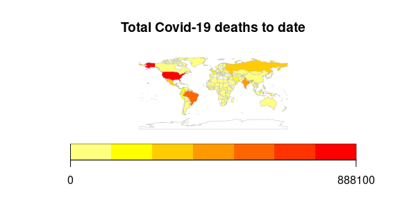

```r
# Produce map
rworldmap::mapCountryData(map_data,
  nameColumnToPlot = "deaths_total",
  catMethod = "fixedWidth",
  mapTitle = "Total Covid-19 deaths to date",
  addLegend = TRUE
)
```